# Make time count! Exposure to words, not hours spent practicing, drives reading progress

A data report

This report provides a detailed overview of the data used for the SSSR poster. In addition it provides the estimates derived from both analyses.

Author

Affiliation

Emiel Schoneveld

University of Amsterdam

Published

July 1, 2026

Keywords

Intervention, Dosage, Time, Words, Accuracy

# 1 Descriptive statistics —-

## 1.1 Histograms and scatterplots

[interactive chart not shown]

# 2 Mediation analysis

## 2.1 Model description

This model is used to investigate whether the reading fluency improvements are caused by the number of words students read and/or the amount of time they have practiced. The model displayed below was fitted with and without the direct effect of time on post to test for full or partial mediation of the time effect on post fluency via words.

**Note**

The covariances are omitted in the figure for legibility.

[interactive chart not shown]

## 2.2 Results

The models were fitted for three outcome measures. Below the standardized estimates of the regression parameters and the full vs partial mediation anova test.

**Note**

Time -> post is empty because the effect of time on post was fully mediated by words in all three models.

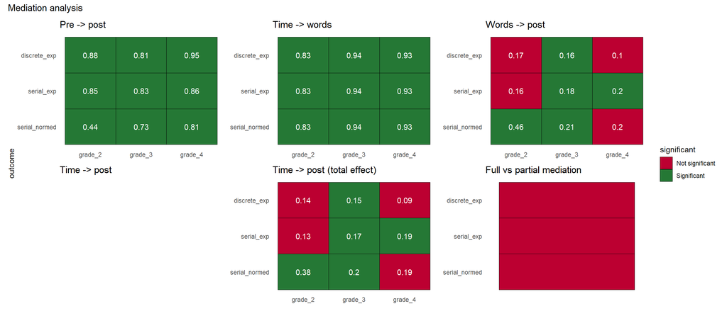

# 3 Interaction analysis

## 3.1 Model description

Using an OLM linear model the following model was fitted to check the influence of accuracy. The effect of time on post was omitted because it was fully mediated by words.

[interactive chart not shown]

## 3.2 The results

The models were fitted for three outcome measures. Below the standardized regression estimates.

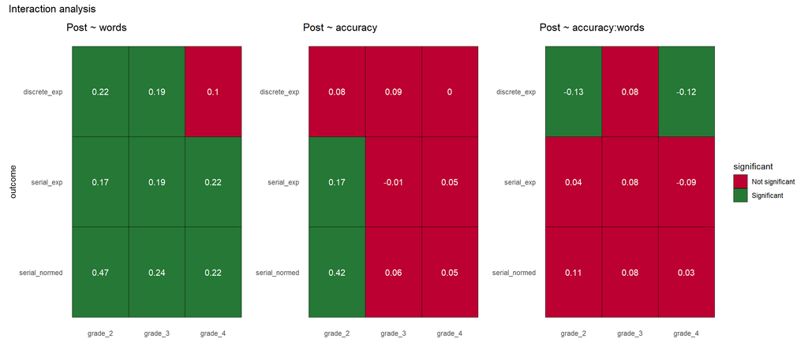